# Capstone Project Swiftkey - Milestone Report

Inderlal Chettri

March 19, 2016

# Introduction

Typing on mobile devices is difficult given their small form factor. Swiftkey has developed a smart software keyboard to reduce the difficulty and increase the typing speed on mobile keyboards. One of the techniques used is predictive text modelling and the objective of this course is to develop a app which will use predictive text analytics to come up with word options given a input phrase.

The objective of this report is to

1. Demonstrate the data has been downloaded and successfully loaded in R.
2. Create a basic report of summary statistics about the data sets.
3. Report any interesting findings.
4. Map next steps and get feedback for creating a prediction algorithm and Shiny app.

### Please skip directly to Section 2.b. Report Analysis and Statistics if you are not interested in the code for getting the data and cleaning it.

# 1. Loading the data

Loading in the libraries used for this assignment

```r
library(data.table)
library(tm)
library(SnowballC)
library(wordcloud)
```

The link to the data to be used for this assignment is provided.

```r
setwd("~/R/Coursera/Capstone")                                      # Set the working folder for the assignment
list.filesDownloadURL <- "https://d396qusza40orc.cloudfront.net/dsscapstone/dataset/Coursera-SwiftKey.zip"                                                                         #The link to the file to be downloaded.
Zipfile <- "./Coursera-SwiftKey.zip"                                # The downloaded file

if(length(list.files(pattern="Coursera-SwiftKey.zip"))==0){         # To prevent multiple downloads
  download.file(DownloadURL,Zipfile, cacheOK = TRUE)                # Download the file
  unzip(Zipfile, files = NULL, list = FALSE, overwrite = TRUE,junkpaths = FALSE, exdir = ".", unzip = "internal", setTimes = FALSE)                                                # Unzip the file
}

rm(list.filesDownloadURL, Zipfile)                                  # Remove variables no longer required.
```

Examining the unzipped directory “final”, we see the english language files are in “./final/en_US/”.

```r
list.files("final", recursive = TRUE, pattern = "^en")
```

```
## [1] "en_US/en_US.blogs.txt"   "en_US/en_US.news.txt"
## [3] "en_US/en_US.twitter.txt"
```

Three text files, named news, blogs and twitter, have been provided for this assignment.

We will now load the files into R data tables for blogs, news and twitter.

```r
blog <- fread("./final/en_US/en_US.blogs.txt", header = FALSE, sep="\n", stringsAsFactors = FALSE, encoding="UTF-8", showProgress = FALSE)

news <- fread("./final/en_US/en_US.news.txt", header = FALSE, sep="\n", stringsAsFactors = FALSE, encoding="UTF-8", showProgress = FALSE)

twitter <- read.table("./final/en_US/en_US.twitter.txt", header = FALSE, sep="\n", quote = "", stringsAsFactors = FALSE,  encoding="UTF-8", skipNul = TRUE)              # Used a different method to load the data because of special characters present in the data.
twitter <- data.table:::as.data.table.list(twitter)
```

# 2.a. Clean and Analyze Data

Evaluating high level statistics of the files that were loaded

```r
data.table("File Name |" = c("blog", "news", "twitter"), "No of Lines |" = c(dim(blog)[1], dim(news)[1], dim(twitter)[1]), "File Size (Mb)" = c(object.size(blog), object.size(news), object.size(twitter))/2^20)
```

```
##    File Name | No of Lines | File Size (Mb)
## 1:        blog        899049       248.4659
## 2:        news       1010228       249.5134
## 3:     twitter       2302307       283.4971
```

Given the size of the data sets, decided to process each of these individually. The process involved the following steps:

1. Create a corpus.
2. Clean the data.
3. Create a Term Document Matrix.

This was done for each data set - blog, news, twitter. Taking blog as an example

```r
b <- VCorpus(VectorSource(blog), readerControl=list(language="english"))       # Create Corpus
b <- tm_map(b, content_transformer(function(x) iconv(x, from = "UTF-8", to="ASCII", sub=""))) #Convert to ASCII
b <- tm_map(b, content_transformer(function(x) gsub("[Hh][Tt][Tt][Pp][[:alnum:][:punct:]]*", "", x)))                                                                                         # Remove links
b <- tm_map(b, content_transformer(tolower))                                   # Convert to lower case
b <- tm_map(b, content_transformer(removePunctuation))                         # Remove punctuation marks
b <- tm_map(b, content_transformer(removeNumbers))                             # Remove numbers
b <- tm_map(b, content_transformer(stripWhitespace))                           # Remove White spaces
b <- tm_map(b, content_transformer(function(x) gsub("^[[:space:]]","", x)))    # Remove beginning space
b <- tm_map(b, content_transformer(function(x) gsub("[[:space:]]$","", x)))    # Remove ending space
b <- tm_map(b, PlainTextDocument)                                              # Convert to Plain Text document
save(b, file = "./data/twitter_b.RData" )                                      # Data saved to hard drive
tdm <- TermDocumentMatrix(b)                                                   # Create a Term Document Matrix
save(tdm, file = "./data/twitter_tdm.RData" )                                  # tdm saved to hard drive
```

Now, we reload each of the tdms and convert them to a sorted data table using the function TDMtoDT().

```r
TDMtoDT <- function(inputtdm){
  m <- as.matrix(inputtdm)
  m <- data.table(cbind("Word"=rownames(m),"Freq"=as.numeric(m)), keep.rownames = FALSE)
  m$Freq <- as.numeric(m$Freq)
  m <- m[order(Freq,decreasing=TRUE)]
}

load("./data/twitter_tdm.RData")
twitter_DT <- TDMtoDT(tdm)
rm(tdm)

load("./data/blog_tdm.RData")
blog_DT <- TDMtoDT(tdm)
rm(tdm)

load("./data/news_tdm.RData")
news_DT <- TDMtoDT(tdm)
rm(tdm)
```

# 2.b. Report Analysis and Statistics

Looking at some of the statistics of the processed data sets

```r
data.table("File Name |" = c("blog_DT", "news_DT", "twitter_DT"), "No of Unique Words |" = c(dim(blog_DT)[1], dim(news_DT)[1], dim(twitter_DT)[1]), "Total No of Words |" = c(sum(blog_DT$Freq), sum(news_DT$Freq), sum(twitter_DT$Freq)), "File Size (Mb)" = c(object.size(blog_DT), object.size(news_DT), object.size(twitter_DT))/2^20)
```

```
##    File Name | No of Unique Words | Total No of Words | File Size (Mb)
## 1:     blog_DT               395555            28810407       26.31971
## 2:     news_DT               309781            27391444       20.61131
## 3:  twitter_DT               408728            21103215       27.14790
```

The top 10 most frequently occurring words in the three data tables are as follows

```r
data.table("Blogs" = head(blog_DT,10), "News" = head(news_DT,10), "Twitter" = head(twitter_DT,10))
```

```
##     Blogs.Word Blogs.Freq News.Word News.Freq Twitter.Word Twitter.Freq
##  1:        the    1855771       the   1971866          the       879926
##  2:        and    1086110       and    884350          you       518743
##  3:       that     459500       for    353028          and       402398
##  4:        for     362867      that    346720          for       360354
##  5:        you     296855      with    254752         that       222870
##  6:       with     286177      said    250348         with       161555
##  7:        was     278002       was    228920         your       160738
##  8:       this     257977       his    157594         have       159424
##  9:       have     218541      from    152124         this       152228
## 10:        but     203446       but    151219          are       148935
```

And plotting the wordclouds for the datasets

For Blogs:

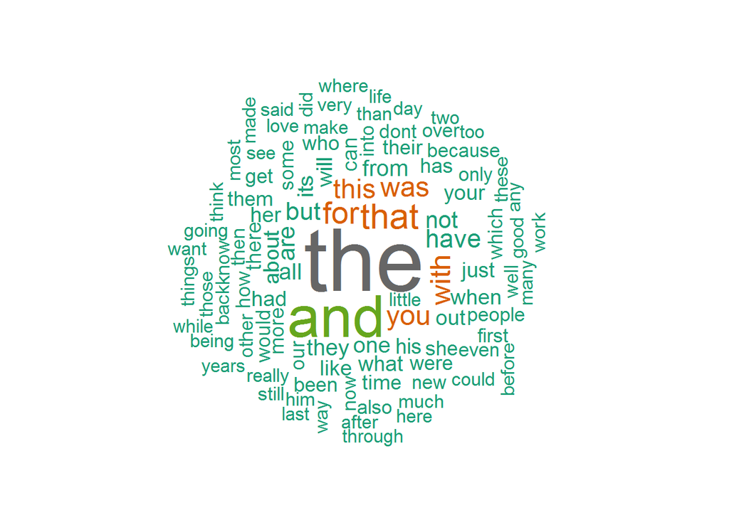

```r
wordcloud(blog_DT$Word[1:100], blog_DT$Freq[1:100], scale=c(5,1), max.words=100, random.order=FALSE, rot.per=0.35, use.r.layout=FALSE, colors=brewer.pal(8, "Dark2"))
```

For News:

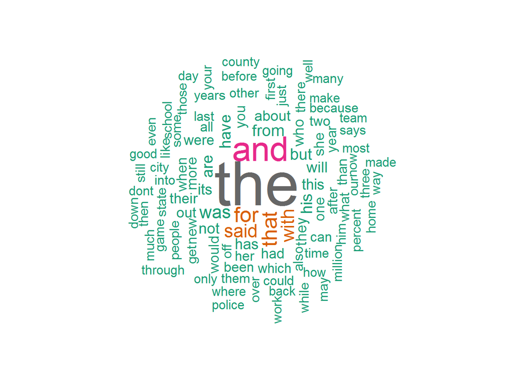

```r
wordcloud(news_DT$Word[1:100], news_DT$Freq[1:100], scale=c(5,1), max.words=100, random.order=FALSE, rot.per=0.35, use.r.layout=FALSE, colors=brewer.pal(8, "Dark2"))
```

For Twitter:

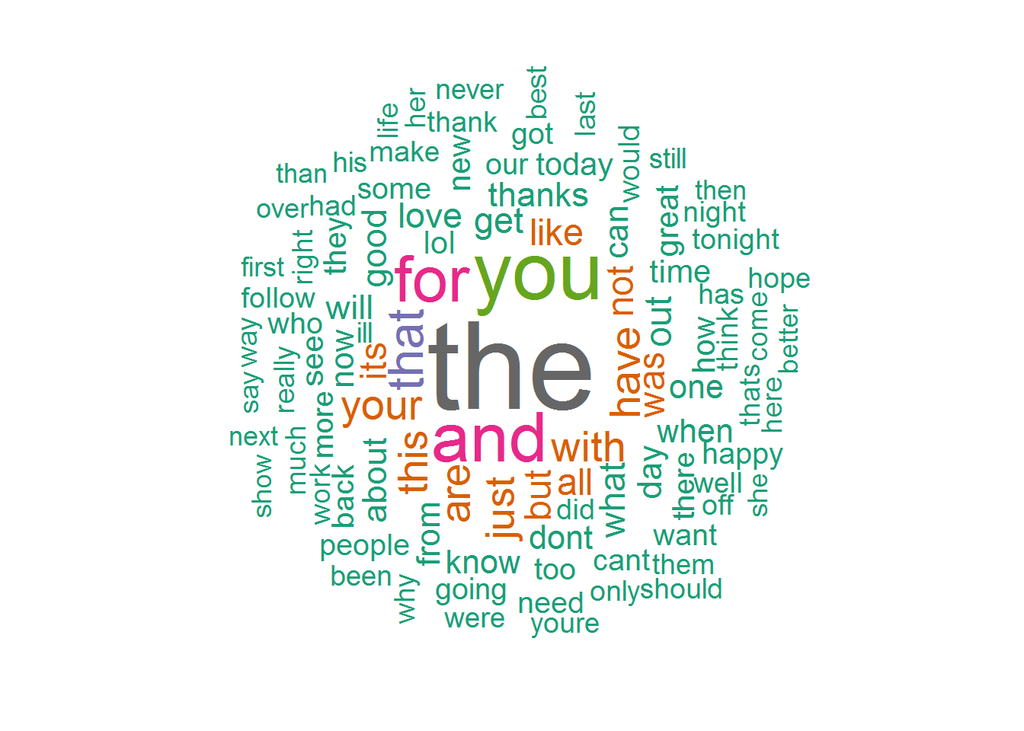

```r
wordcloud(twitter_DT$Word[1:100], twitter_DT$Freq[1:100], scale=c(5,1), max.words=100, random.order=FALSE, rot.per=0.35, use.r.layout=FALSE, colors=brewer.pal(8, "Dark2"))
```

Plotting the frequency of occurances for words in each data set

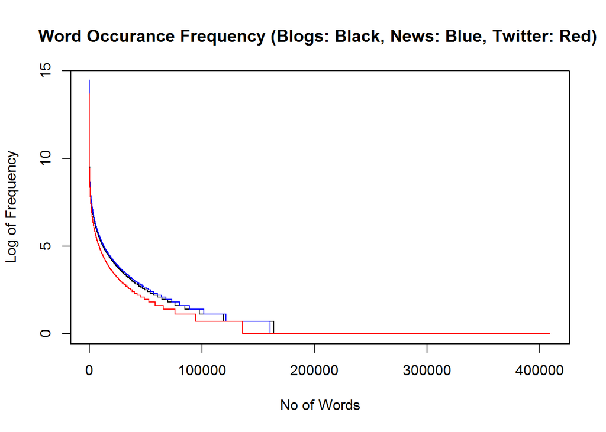

```r
options(scipen=10000)
plot(log(blog_DT$Freq), type = "l", col = "black", xlim = c(0,410000), xlab="No of Words",ylab="Log of Frequency",main="Word Occurance Frequency (Blogs: Black, News: Blue, Twitter: Red) ")
lines(log(news_DT$Freq), col="blue")
lines(log(twitter_DT$Freq), col="red")
```

Integrating the tree data sets and plotting the graph and word cloud

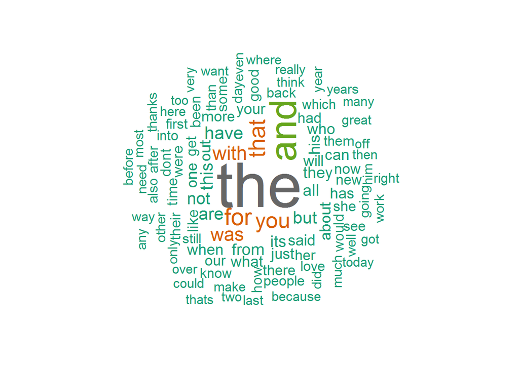

```r
Combine_DT <- merge(news_DT, blog_DT, by = "Word", all = TRUE)
Combine_DT <- merge(Combine_DT, twitter_DT, by = "Word", all = TRUE)
Combine_DT<- Combine_DT[ ,sum := rowSums( .SD, na.rm = TRUE), .SDcols = c("Freq.x", "Freq.y", "Freq")]
Combine_DT[ ,grep("Freq", colnames(Combine_DT)):=NULL]
Combine_DT <- Combine_DT[order(sum,decreasing=TRUE)]

wordcloud(Combine_DT$Word[1:100], Combine_DT$sum[1:100], scale=c(5,1), max.words=100, random.order=FALSE, rot.per=0.35, use.r.layout=FALSE, colors=brewer.pal(8, "Dark2"))
```

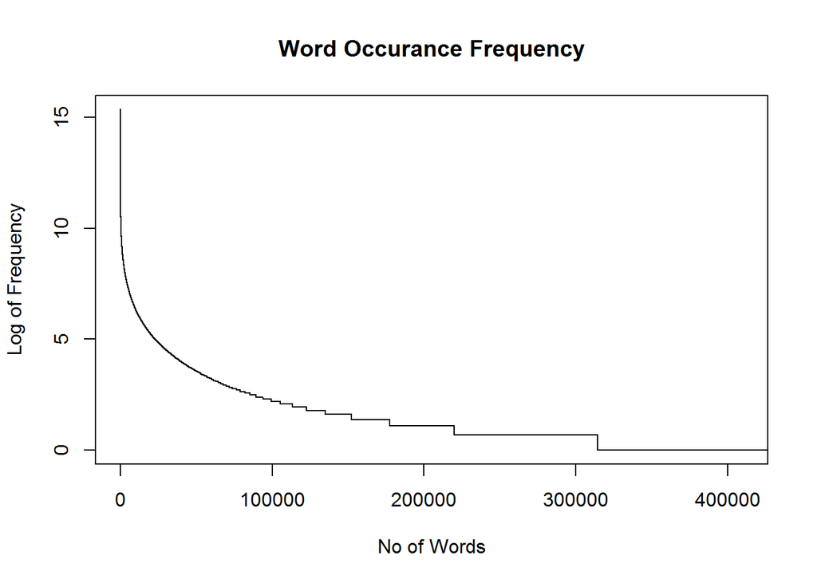

```r
plot(log(Combine_DT$sum), type = "l", col = "black", xlim = c(0,410000), xlab="No of Words",ylab="Log of Frequency",main="Word Occurance Frequency")
```

Looking at the data, it is clear that there will be a minimal loss of accuracy by taking just a small subset of the data to build the word prediction application. We should be able to proceed ahead by taking a random 10% sample of the data.

# 3. Interesting Findings

Looking at the analysis, we note that there is a great amount of similarity across the three data sets

# 4. Going Forward

1. I am planning to use a 10% random sample for the rest of the project. Will use that to build the algorithms and compute the n-grams.
2. Review different models including Katz back-off, Kneser-Ney, etc.
3. Build the algorithm for predicting the next word
4. Build a Shiny app
5. Build presentation